# Fonville, 2016 Human and Ferret Maps

Amanda Skarlupka

12/29/2022

# Purpose of this code:

This code takes the raw data from the Fonville 2016 paper and creates AcMap datafiles from the HAI data from both the ferrets and human HAIs. The HAI data is only for the H3N2 viruses only.

# Products of this code:

```
##
##
##
##
##
## here() starts at D:/Research/Ag-Dist
##
```

# Datasets:

- Dataset S1: The season; corresponding weeks of influenza A/H3N2 incidence exceeding 10 cases of influenza-like-illness (ILI) per 10.000 inhabitants in the Netherlands; the sample selection window based on 2 weeks around the epidemic interval; and the virus used to screen for influenza virus-positive samples.
- Dataset S2: Sample information, screening titers and full hemagglutination inhibition (HI) data set of titers against 23 test viruses of all influenza virus-positive children’s sera.
- Dataset S3: HI titers of 24 ferret sera to the 23 test viruses
- Dataset S4: The subset of the HI table used to calculate the antigenic map based on the high-responding human sera (Figure 2).
- Dataset S5: The subset of the HI table used to calculate the antigenic map of ferret sera in Figure 3 using the same subset of viruses as Dataset S4.
- Dataset S6: The subset of the HI table used to calculate the antigenic map based on all human sera that had at least one titer of 240 or higher (Figure 4A, B).
- Dataset S7: The subset of the HI table used to calculate the antigenic map of ferret sera in Figure 4C, D using the same subset of viruses as Dataset S6.

## Acmaps

### Dataset S5

Ferret acmap using Dataset 5

```r
ferret_titer_table <- list_with_sheets[["Dataset S5"]] # Fonville HAI titer table

  names <- ferret_titer_table$virus

Racmacs::make.acmap(
  titer_table = ferret_titer_table[,-1],
  number_of_dimensions = 2,
  number_of_optimizations = 100,
  ag_names = names,
  sr_names = colnames(ferret_titer_table)[-1]
) %>%
  Racmacs::save.acmap(.,
             filename = here::here("data/processed/h3_maps/fonville_ferret_ds5.ace"))
```

```
## a
```

```
## Took 0.08 secs
```

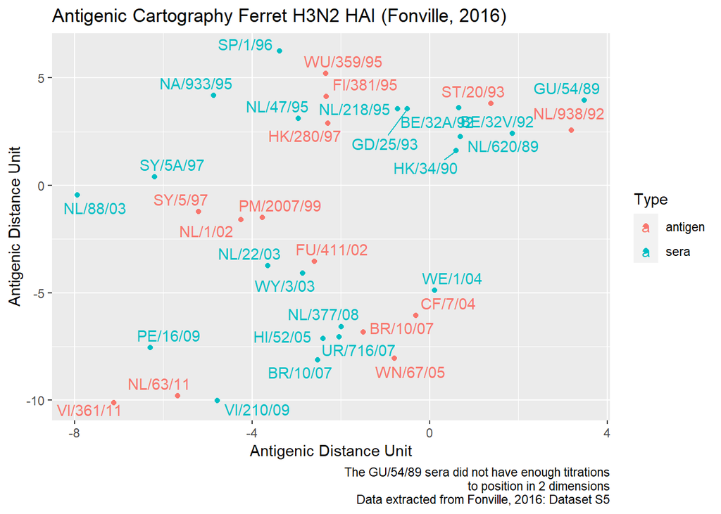

```r
#The GU/54/89 sera cannot be placed in a 2D map and a message should be received

fonville_df <- AcmapToDF(map = read.acmap(here::here("data/processed/h3_maps/fonville_ferret_ds5.ace")))

fonville_df %>%
  ggplot2::ggplot(aes(x = V1,
             y = V2,
             color = type)) +
  ggplot2::geom_point() +
  ggrepel::geom_text_repel(label = fonville_df$identifier) +
  ggplot2::labs(title = "Antigenic Cartography Ferret H3N2 HAI (Fonville, 2016)",
       caption = "The GU/54/89 sera did not have enough titrations\nto position in 2 dimensions\nData extracted from Fonville, 2016: Dataset S5",
       color = "Type") +
  ggplot2::xlab("Antigenic Distance Unit") +
  ggplot2::ylab("Antigenic Distance Unit")
```

Smith Cartography without down selection:

There are 273 Viral isolates that the HAI were tested against There are 79 post infection ferret antisera

```
## a
```

```
## Took 5.03 secs
```

Compares the Smith Ferret HAIs to the Fonville Ferret HAIs

Comparison of the Smith and Fonville HAI data

H3N2 ferret sera used in HAI panel

Virus

Study

GU/54/89

NL/620/89

HK/34/90

BE/32A/92

BE/32V/92

GD/25/93

NA/933/95

NL/47/95

NL/218/95

SP/1/96

SY/5A/97

NL/22/03

NL/88/03

NL/938/92

Smith

1280

6451

479

100

NL/938/92

Fonville

160

480

2560

1920

1280

60

80

ST/20/93

Smith

402

421

3840

80

ST/20/93

Fonville

480

480

640

7680

320

320

40

480

960

30

FI/381/95

Smith

20

70

640

100

531

867

FI/381/95

Fonville

160

1280

80

320

1920

2560

640

240

320

30

WU/359/95

Smith

481

185

167

861

113

WU/359/95

Fonville

240

80

480

40

60

5120

320

240

960

480

HK/280/97

Smith

516

96

640

HK/280/97

Fonville

80

480

1920

120

240

10240

1280

480

1920

640

80

80

SY/5/97

Smith

3541

320

1280

SY/5/97

Fonville

40

40

160

80

20

10240

320

480

PM/2007/99

Smith

1753

320

1280

PM/2007/99

Fonville

160

240

80

30

320

120

10

10240

3840

5120

FU/411/02

Smith

10

2342

101

FU/411/02

Fonville

160

20

40

30

320

1920

60

NL/1/02

Smith

25

166

15

240

560

640

NL/1/02

Fonville

30

120

160

30

20

320

640

160

* Values that are <10 or <5

```
## a
```

```
## Took 0.02 secs
```

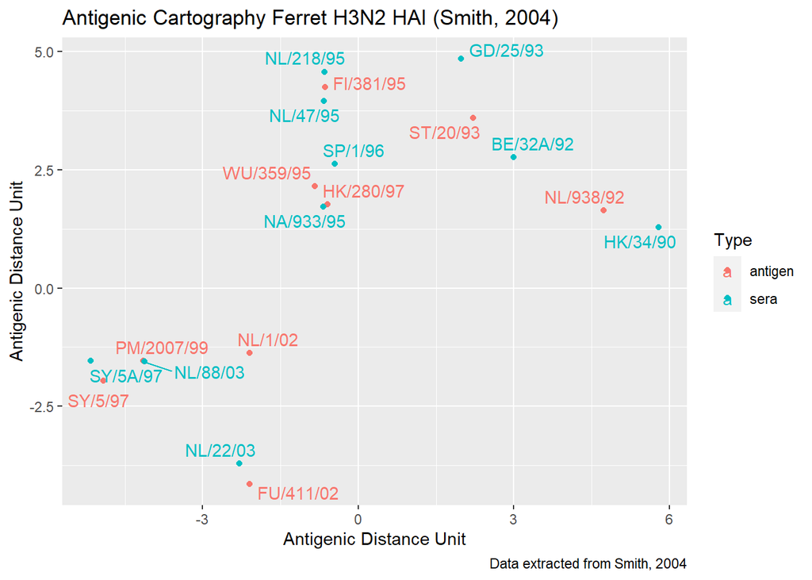

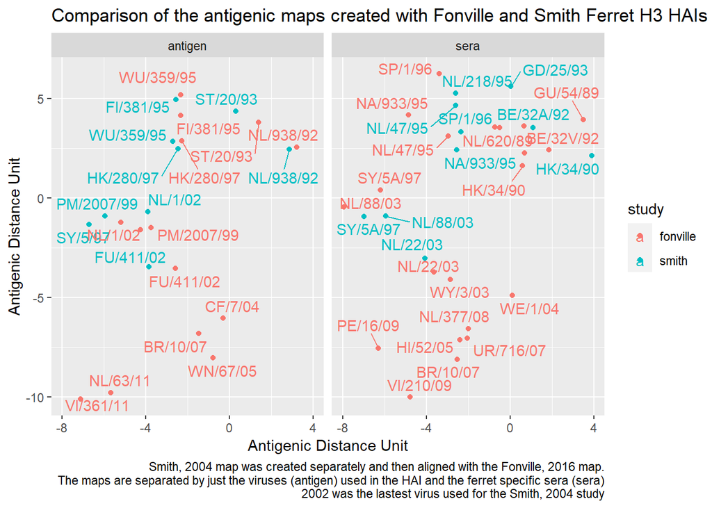

## Dataset S4

Human acmap using Dataset 4.

```r
human_titer_table <- list_with_sheets[["Dataset S4"]]
names <- human_titer_table$virus

Racmacs::make.acmap(
  titer_table = human_titer_table[,-1],
  number_of_dimensions = 2,
  number_of_optimizations = 100,
  ag_names = names,
  sr_names = colnames(human_titer_table)[-1]
) %>%
  Racmacs::save.acmap(., filename = here::here("data/processed/h3_maps/fonville_human_ds4.ace"))
```

```
## a
```

```
## Took 0.02 secs
```

```r
#Expected Warning: The following ANTIGENS have do not have enough titrations to position in 2 dimensions. Coordinates were still optimized but positions will be unreliable

#'NL/938/92'
#'ST/20/93'
#'BR/10/07'
#'Since this is the data that is available, this will have to do
```